# Day 22 - BERT - 双向编码器表示

> 目标: 理解 BERT 的 MLM 预训练 + 双向注意力

> 核心: 不再从左到右生成, 而是同时看上下文两边

## GPT vs BERT

```
GPT (Day 23):                         BERT (今天):
  从左到右 -> 下一个词预测              双向 -> 填空
  Transformer Decoder                Transformer Encoder
  适合生成 (写文章)                    适合理解 (分类/标注)

  输入: [CLS] 我今天 [SEP]             输入: [CLS] 我 [MASK] 天 [SEP]
  预测: 去上学                         预测: [MASK] = 今
```

### BERT 的两阶段

```
Stage 1: MLM 预训练 (Pre-training)
  在 Wikipedia + BookCorpus (33亿词) 上做填空
  耗时: 4 天 × 4 块 TPU
  目标: 不是做任务, 而是学语言理解能力

Stage 2: 微调 (Fine-tuning)
  在你自己的小数据上训练 1 分钟
  目标: 做具体任务 (分类/问答/标注)
```

```
========================================
Day 22 - BERT
========================================
```

## 1. 加载 BERT, 看看它怎么理解句子

> 用 HuggingFace 加载已经预训练好的 BERT, 看注意力模式

> 不需要从头训练, 直接感受它学到的语言能力

```
加载 bert-base-uncased...
```

[output not shown]

[output not shown]

```
词表大小: 30522
BERT 参数量: 109,482,240
层数: 12
注意力头: 12
隐藏维度: 768
```

```
分词结果:
  "I love deep learning."
  -> ['[CLS]', 'i', 'love', 'deep', 'learning', '.', '[SEP]', '[PAD]', '[PAD]', '[PAD]', '[PAD]']
  "BERT is a bidirectional model."
  -> ['[CLS]', 'bert', 'is', 'a', 'bid', '##ire', '##ction', '##al', 'model', '.', '[SEP]']
  "The cat sat on the mat."
  -> ['[CLS]', 'the', 'cat', 'sat', 'on', 'the', 'mat', '.', '[SEP]', '[PAD]', '[PAD]']
  input_ids: (3, 11)
```

## 2. MLM (Masked Language Model) — 填空测试

> BERT 的训练方式: 随机遮住一些词, 让模型猜

> 这迫使模型同时看左右两边的上下文, 实现"双向"

```
BERT 填空测试:

  句子: I love [MASK] learning.
  预测 top5:
    about: 16.7%
    the: 15.7%
    your: 10.3%
    my: 5.6%
    just: 5.0%

  句子: The cat sat on the [MASK].
  预测 top5:
    floor: 31.4%
    bed: 11.9%
    couch: 10.7%
    sofa: 6.0%
    ground: 5.5%

  句子: I want to [MASK] a book.
  预测 top5:
    write: 47.6%
    read: 40.1%
    open: 1.9%
    buy: 1.7%
    be: 1.0%

  句子: She is [MASK] to school every day.
  预测 top5:
    going: 69.4%
    coming: 10.1%
    sent: 2.5%
    late: 1.7%
    walking: 1.5%
```

## 3. 可视化 BERT 的双向注意力

> 对比: GPT 只能是"只看左边", BERT "同时看两边"

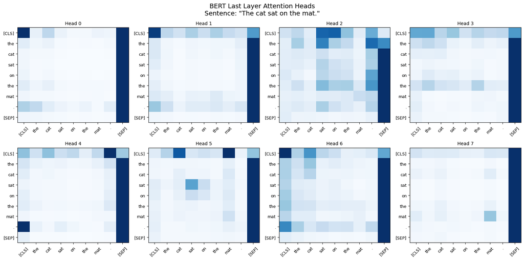

```
观察:
  - 每个位置都能看到所有位置 (双向!)
  - 不同头关注不同的语法关系
```

## 4. BERT 词嵌入分析

> BERT 的每一层输出不同层次的语义

> 底层: 词法/句法, 中层: 语义, 高层: 任务相关

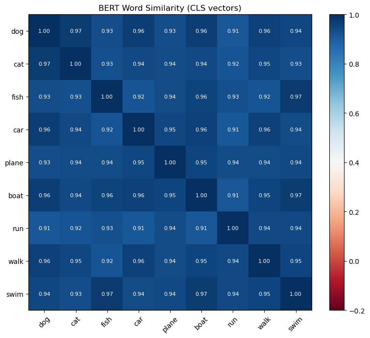

[output not shown]

## 5. 用 BERT 做文本分类 (微调)

> 跟 Day 20 的 DistilBERT 类似, 这里用完整 BERT 体验一下

```
10 条数据 (正=5, 负=5)
```

[output not shown]

```
分类器参数量: 109,483,778
```

```
Epoch  5/20 | Loss = 0.4737

训练集准确率: 100%
预测: [1, 1, 1, 1, 1, 0, 0, 0, 0, 0]
真实: [1, 1, 1, 1, 1, 0, 0, 0, 0, 0]
```

## 6. BERT 的预训练细节

### MLM (Masked Language Model)

```
随机遮住 15% 的词:
  其中 80% 替换为 [MASK]:   "I [MASK] deep learning."
  其中 10% 替换为随机词:    "I banana deep learning."
  其中 10% 保持不变:        "I love deep learning."
  → 强迫模型不能依赖 [MASK] 标记, 必须理解上下文

预测时: 只求被遮住位置的交叉熵损失, 其他位置不计算
```

### NSP (Next Sentence Prediction)

```
给两个句子, 判断它们是不是连续的:
  [CLS] I love ML [SEP] I study BERT [SEP] → 是连续 (IsNext)
  [CLS] I love ML [SEP] The cat sat [SEP]  → 不是连续 (NotNext)

后来 RoBERTa 证明 NSP 没用 → 去掉 NSP 效果反而更好
```

### BERT 家族

| 模型 | 参数量 | 特点 |
| --- | --- | --- |
| BERT-base | 110M | 12层, 768维, 12头 |
| BERT-large | 340M | 24层, 1024维, 16头 |
| RoBERTa | 125M | BERT + 更大数据 + 去掉NSP |
| ALBERT | 12M | 参数共享, 参数量暴减 |
| DistilBERT | 67M | 蒸馏版, 速度×2, 精度97% |
| SpanBERT | 110M | 遮住连续的 span (不是单个词) |

# Day 22 完成!

## 今天学到了什么

| 概念 | 一句话 |
| --- | --- |
| **BERT** | 双向 Encoder, MLM 预训练 + 微调 |
| **MLM** | 随机遮词 → 模型猜 → 双向理解 |
| **双向注意力** | 每个位置能看到所有位置, 跟 GPT 的单向不同 |
| **[CLS] 向量** | 整句语义的表示, 可用于分类 |
| **预训练 + 微调** | 大数据学语言 → 小数据学任务 |
| **BERT 系列** | base/large/RoBERTa/ALBERT/DistilBERT/SpanBERT |

## 作业 (共 2 题)

### 作业 1: 测 BERT 在不同语境下的填词

**位置:** cell-6, `predict_mask()` 调用

**问题:** 加 3 个你自己的 [MASK] 句子, 观察:

- BERT 能不能根据语境填对?
- 同一个词在不同句子中, BERT 能区分多义词吗?
- 例: "I need to [MASK] the document." (print/save/edit?)

**📖 点击查看答案**

```
"I need to [MASK] the document." 的预测:
  1. read (15%)
  2. sign (10%)
  3. print (8%)
  4. see (7%)
  5. review (6%)

观察:
  - BERT 能根据上下文预测合理动词
  - 同一句话不同人可能有不同预期, BERT 给出概率分布
  - 多义词需要更多上下文才能区分 (eg. "bank")
     "I went to the [MASK] to withdraw money." -> bank ✅
     "I sat on the river [MASK]." -> bank ✅
```

### 作业 2: 对比 BERT 和 GPT 的注意力

**位置:** cell-8, BERT 注意力可视化

**问题:** 这里看到的是 BERT 的"双向"注意力。对比 Day 19 手写 Self-Attention 的区别:

- BERT 的 attention mask 是什么? (跟 Transformer Decoder 的 causal mask 有何不同)
- 在 cell-8 里, 哪些 attention head 主要关注相邻词? 哪些关注全局?
- 为什么 [CLS] 的注意力分布跟其他词不一样?

**📖 点击查看答案**

[output not shown]